# Occupancy model for *Ateles geoffroyii* standard single season model

version 1

Ron A. Fernández-Gómez

2026-04-17

```r
library(unmarked)
library(tidyverse)
library(MuMIn)
library(corrplot)
library(AICcmodavg)
library(knitr)
```

## 1 Detection histories

Matriz con las detecciones acusticas de **mono araña** usando el modelo V3 y que fueron valiadas por expertos. Las detecciónes provienen de audios de 42 unidades de grabación que fueron desplegadas en la Selva Maya en la Península de Yucatán entre diciembre 2024 a enero 2025

```r
det.his <- read.csv("detectATEGEO-2.csv", row.names = "X")
head(det.his)
```

|  | day.1 | day.2 | day.3 | day.4 | day.5 | day.6 | day.7 | day.8 | day.9 | day.10 | day.11 | day.12 | day.13 | day.14 | day.15 | day.16 | day.17 | day.18 | day.19 | day.20 | day.21 | day.22 | day.23 | day.24 | day.25 | day.26 | day.27 | day.28 |
| --- | --- | --- | --- | --- | --- | --- | --- | --- | --- | --- | --- | --- | --- | --- | --- | --- | --- | --- | --- | --- | --- | --- | --- | --- | --- | --- | --- | --- |
| R101 | 1 | 1 | 1 | 0 | 0 | 0 | 1 | 0 | 0 | 0 | 1 | 0 | 0 | 1 | 0 | 0 | 0 | 0 | 0 | NA | NA | NA | NA | NA | NA | NA | NA | NA |
| R102 | NA | 0 | 0 | 0 | 0 | 0 | 0 | 0 | 0 | 0 | NA | NA | NA | NA | NA | NA | NA | NA | NA | NA | NA | NA | NA | NA | NA | NA | NA | NA |
| R103 | 0 | 0 | 0 | 0 | 0 | 0 | 0 | 0 | 0 | 0 | 0 | 0 | 0 | 0 | 0 | 0 | 0 | 0 | 0 | NA | NA | NA | NA | NA | NA | NA | NA | NA |
| R104 | 0 | 1 | 0 | 0 | 0 | 0 | 1 | 0 | 0 | 0 | 0 | 0 | 0 | 0 | 0 | 0 | 0 | 0 | 0 | 0 | NA | NA | NA | NA | NA | NA | NA | NA |
| R105 | 0 | 0 | 0 | 0 | 0 | 0 | 0 | 0 | 0 | 0 | 0 | 0 | 0 | 0 | 0 | 0 | NA | NA | NA | NA | NA | NA | NA | NA | NA | NA | NA | NA |
| R106 | 0 | 0 | 0 | 0 | 1 | 0 | 0 | 0 | 0 | 0 | 0 | 0 | 0 | 1 | 0 | 0 | 0 | 0 | 0 | 0 | NA | NA | NA | NA | NA | NA | NA | NA |

## 2 The covariates

### 2.1 Sampling effort covariates

```r
effort <- read.csv("effort.csv", row.names = "X")
head(effort)
```

|  | Eff.1 | Eff.2 | Eff.3 | Eff.4 | Eff.5 | Eff.6 | Eff.7 | Eff.8 | Eff.9 | Eff.10 | Eff.11 | Eff.12 | Eff.13 | Eff.14 | Eff.15 | Eff.16 | Eff.17 | Eff.18 | Eff.19 | Eff.20 | Eff.21 | Eff.22 | Eff.23 | Eff.24 | Eff.25 | Eff.26 | Eff.27 | Eff.28 |
| --- | --- | --- | --- | --- | --- | --- | --- | --- | --- | --- | --- | --- | --- | --- | --- | --- | --- | --- | --- | --- | --- | --- | --- | --- | --- | --- | --- | --- |
| R101 | 204 | 480 | 480 | 480 | 480 | 480 | 480 | 480 | 480 | 480 | 480 | 480 | 480 | 480 | 480 | 480 | 480 | 480 | 480 | 0 | 0 | 0 | 0 | 0 | 0 | 0 | 0 | 0 |
| R102 | 0 | 171 | 480 | 479 | 480 | 480 | 480 | 480 | 480 | 237 | 0 | 0 | 0 | 0 | 0 | 0 | 0 | 0 | 0 | 0 | 0 | 0 | 0 | 0 | 0 | 0 | 0 | 0 |
| R103 | 69 | 480 | 480 | 480 | 480 | 480 | 480 | 480 | 480 | 480 | 480 | 480 | 480 | 480 | 480 | 480 | 480 | 480 | 394 | 0 | 0 | 0 | 0 | 0 | 0 | 0 | 0 | 0 |
| R104 | 127 | 480 | 480 | 480 | 480 | 480 | 480 | 480 | 480 | 480 | 480 | 480 | 480 | 480 | 480 | 480 | 480 | 480 | 480 | 19 | 0 | 0 | 0 | 0 | 0 | 0 | 0 | 0 |
| R105 | 109 | 480 | 480 | 480 | 480 | 480 | 480 | 480 | 480 | 480 | 480 | 480 | 480 | 480 | 480 | 480 | 0 | 0 | 0 | 0 | 0 | 0 | 0 | 0 | 0 | 0 | 0 | 0 |
| R106 | 96 | 480 | 480 | 480 | 480 | 480 | 480 | 480 | 480 | 480 | 480 | 480 | 480 | 480 | 480 | 480 | 480 | 480 | 480 | 51 | 0 | 0 | 0 | 0 | 0 | 0 | 0 | 0 |

### 2.2 Site covariates

En este punto se incluyeron como covariables medidas de la diversidad de aves a partir de PAM en los sitios de muestreo. Se usó el modelo `BirdNET Global v2.4` para detectar aves presentes, se usó un *threshold* conservador de 0.9 de *confidence score* y se validó los registros de presencia de especies con distribución y ocurrencia de las especies en el área de estudio. Se incluye una variable de esfuerzo de muestreo en minutos de audio para controlar por dierencias en la cantidad de audios procesados.

### 2.3 Dimensions of bird diversity

Use la aproximación de diversidad verdadera, por lo que calcule series de Hill para obtener tres órdenes de diversidad que inclyen correcciones sobre especies raras y dominantes: q0=riqueza (mismo peso para todas las especies), q1=Shannon efectivo (especies típicas), y q2=Simpson efectivo (especies dominantes).

```r
site_cov <- read.csv("covBIRDS.csv", row.names = "X")
names(site_cov)
```

```
## [1] "div.q0rich"  "div.q1shan"  "div.q2simp"  "eff.recmins"
```

```r
head(site_cov)
```

|  | div.q0rich | div.q1shan | div.q2simp | eff.recmins |
| --- | --- | --- | --- | --- |
| R101 | 48.069 | 20.593 | 12.322 | 2948 |
| R102 | 117.100 | 34.809 | 18.421 | 1256 |
| R103 | 85.369 | 29.609 | 14.462 | 2875 |
| R104 | 63.033 | 24.599 | 15.531 | 2929 |
| R105 | 37.495 | 23.870 | 17.235 | 2436 |
| R106 | 43.638 | 27.547 | 18.471 | 2929 |

## 3 Plot of detection histories

se grafica la ventana temporal de las detecciones usando un objeto *unmarked*

```r
unm_det.his <- unmarkedFrameOccu(y = as.matrix(det.his))
summary(unm_det.his)
```

```
## unmarkedFrame Object
##
## 42 sites
## Maximum number of observations per site: 28
## Mean number of observations per site: 18.71
## Sites with at least one detection: 25
##
## Tabulation of y observations:
##    0    1 <NA>
##  671  115  390
```

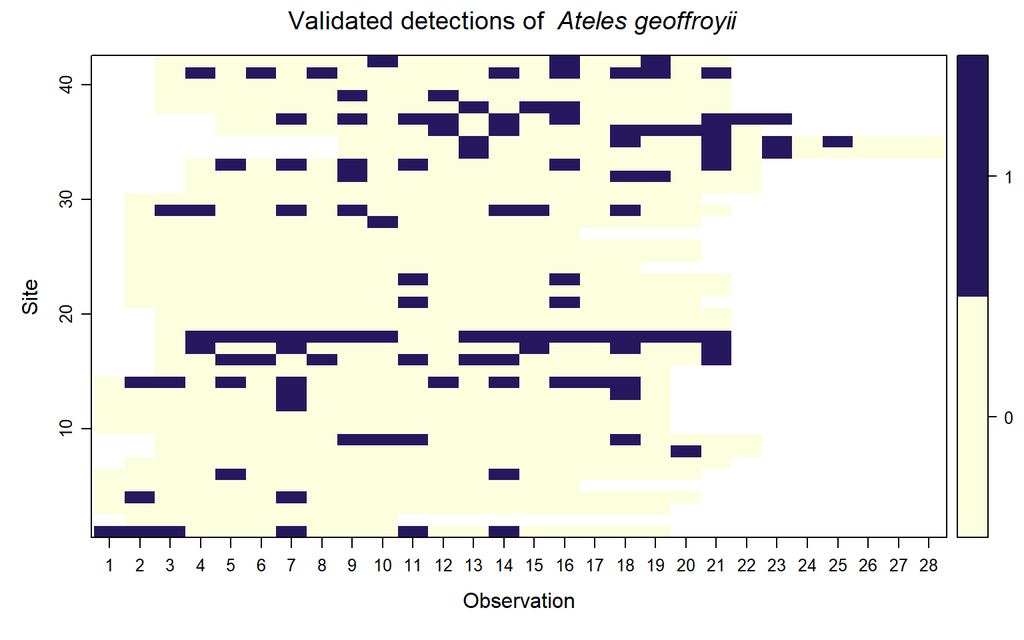

```r
plot(unm_det.his,main = expression("Validated detections of " ~ italic("Ateles geoffroyii")))
```

## 4 Naive detection

ocupacion consderando proprcion de istios con al menos una deteccion

```r
naive_occ <- sum(ifelse(rowSums(det.his, na.rm = TRUE) > 0, 1, 0)) / nrow(det.his)
naive_occ
```

```
## [1] 0.5952381
```

## 5 Null model

Modelo con deteccion y ocupacion constante

```r
null.mod <- occu(~1 ~1, data = unm_det.his)
summary(null.mod)
```

```
##
## Call:
## occu(formula = ~1 ~ 1, data = unm_det.his)
##
## Occupancy (logit-scale):
##  Estimate   SE   z P(>|z|)
##     0.415 0.32 1.3   0.195
##
## Detection (logit-scale):
##  Estimate    SE     z  P(>|z|)
##     -1.17 0.109 -10.7 6.22e-27
##
## AIC: 589.7694
## Number of sites: 42
```

```r
# probabilidad de detección
p_null <- backTransform(null.mod, type = "det")
p_null
```

```
## Backtransformed linear combination(s) of Detection estimate(s)
##
##  Estimate     SE LinComb (Intercept)
##     0.237 0.0197   -1.17           1
##
## Transformation: logistic
```

```r
# probabilidad de ocupación
psi_null <- backTransform(null.mod, type = "state")
psi_null
```

```
## Backtransformed linear combination(s) of Occupancy estimate(s)
##
##  Estimate     SE LinComb (Intercept)
##     0.602 0.0766   0.415           1
##
## Transformation: logistic
```

## 6 Standarization of covariates

estandarización de las covariables

```r
site_cov <- stdize(site_cov)
effort <- stdize(effort)

head(site_cov)
```

|  | z.div.q0rich | z.div.q1shan | z.div.q2simp | z.eff.recmins |
| --- | --- | --- | --- | --- |
| R101 | 0.08203192 | -0.9982380 | -1.43043664 | 0.31768404 |
| R102 | 4.17086782 | 1.8710222 | 0.30286290 | -5.43120791 |
| R103 | 2.29138104 | 0.8214898 | -0.82226136 | 0.06965265 |
| R104 | 0.96837777 | -0.1896943 | -0.51845792 | 0.25312793 |
| R105 | -0.54428598 | -0.3368307 | -0.03419125 | -1.42193338 |
| R106 | -0.18042454 | 0.4053098 | 0.31707260 | 0.25312793 |

```r
head(effort)
```

|  | z.Eff.1 | z.Eff.2 | z.Eff.3 | z.Eff.4 | z.Eff.5 | z.Eff.6 | z.Eff.7 | z.Eff.8 | z.Eff.9 | z.Eff.10 | z.Eff.11 | z.Eff.12 | z.Eff.13 | z.Eff.14 | z.Eff.15 | z.Eff.16 | z.Eff.17 | z.Eff.18 | z.Eff.19 | z.Eff.20 | z.Eff.21 | z.Eff.22 | z.Eff.23 | z.Eff.24 | z.Eff.25 | z.Eff.26 | z.Eff.27 | z.Eff.28 |
| --- | --- | --- | --- | --- | --- | --- | --- | --- | --- | --- | --- | --- | --- | --- | --- | --- | --- | --- | --- | --- | --- | --- | --- | --- | --- | --- | --- | --- |
| R101 | 1.5475673 | 1.57309672 | 0.7844208 | 0.4012290 | 0.2985518 | 0.2209288 | 0.2209288 | 0.2209288 | 0.2209278 | 0.1543033 | 0.1543033 | 0.1543033 | 0.1543033 | 0.1543033 | 0.1543033 | 0.1801213 | 0.2740284 | 0.344890 | 0.3979628 | -1.417398 | -0.9172287 | -0.4750815 | -0.2740284 | -0.2209288 | -0.2209288 | -0.2209288 | -0.2209288 | -0.2180927 |
| R102 | -0.4892310 | 0.01393609 | 0.7844208 | 0.3943871 | 0.2985518 | 0.2209288 | 0.2209288 | 0.2209288 | 0.2209278 | -6.3264373 | -6.3264373 | -6.3264373 | -6.3264373 | -6.3264373 | -6.3264373 | -6.2241914 | -3.5623695 | -3.001108 | -2.9131927 | -1.417398 | -0.9172287 | -0.4750815 | -0.2740284 | -0.2209288 | -0.2209288 | -0.2209288 | -0.2209288 | -0.2180927 |
| R103 | 0.1996861 | 1.57309672 | 0.7844208 | 0.4012290 | 0.2985518 | 0.2209288 | 0.2209288 | 0.2209288 | 0.2209278 | 0.1543033 | 0.1543033 | 0.1543033 | 0.1543033 | 0.1543033 | 0.1543033 | 0.1801213 | 0.2740284 | 0.344890 | -0.1952859 | -1.417398 | -0.9172287 | -0.4750815 | -0.2740284 | -0.2209288 | -0.2209288 | -0.2209288 | -0.2209288 | -0.2180927 |
| R104 | 0.7787758 | 1.57309672 | 0.7844208 | 0.4012290 | 0.2985518 | 0.2209288 | 0.2209288 | 0.2209288 | 0.2209278 | 0.1543033 | 0.1543033 | 0.1543033 | 0.1543033 | 0.1543033 | 0.1543033 | 0.1801213 | 0.2740284 | 0.344890 | 0.3979628 | -1.333234 | -0.9172287 | -0.4750815 | -0.2740284 | -0.2209288 | -0.2209288 | -0.2209288 | -0.2209288 | -0.2180927 |
| R105 | 0.5990583 | 1.57309672 | 0.7844208 | 0.4012290 | 0.2985518 | 0.2209288 | 0.2209288 | 0.2209288 | 0.2209278 | 0.1543033 | 0.1543033 | 0.1543033 | 0.1543033 | 0.1543033 | 0.1543033 | 0.1801213 | -3.5623695 | -3.001108 | -2.9131927 | -1.417398 | -0.9172287 | -0.4750815 | -0.2740284 | -0.2209288 | -0.2209288 | -0.2209288 | -0.2209288 | -0.2180927 |
| R106 | 0.4692623 | 1.57309672 | 0.7844208 | 0.4012290 | 0.2985518 | 0.2209288 | 0.2209288 | 0.2209288 | 0.2209278 | 0.1543033 | 0.1543033 | 0.1543033 | 0.1543033 | 0.1543033 | 0.1543033 | 0.1801213 | 0.2740284 | 0.344890 | 0.3979628 | -1.191483 | -0.9172287 | -0.4750815 | -0.2740284 | -0.2209288 | -0.2209288 | -0.2209288 | -0.2209288 | -0.2180927 |

## 7 Full unmarked object

se construye el objeto de datos de ocupación con todas las covariables de sitio y observación

```r
ategeo <- unmarkedFrameOccu(
  y = as.matrix(det.his),
  siteCovs = site_cov,
  obsCovs = list(effort = effort)
)

summary(ategeo)
```

```
## unmarkedFrame Object
##
## 42 sites
## Maximum number of observations per site: 28
## Mean number of observations per site: 18.71
## Sites with at least one detection: 25
##
## Tabulation of y observations:
##    0    1 <NA>
##  671  115  390
##
## Site-level covariates:
##   z.div.q0rich      z.div.q1shan      z.div.q2simp      z.eff.recmins
##  Min.   :-1.4334   Min.   :-1.9850   Min.   :-1.79307   Min.   :-5.4312
##  1st Qu.:-0.5443   1st Qu.:-0.7806   1st Qu.:-0.81139   1st Qu.: 0.2531
##  Median :-0.1904   Median :-0.1510   Median :-0.04499   Median : 0.3228
##  Mean   : 0.0000   Mean   : 0.0000   Mean   : 0.00000   Mean   : 0.0000
##  3rd Qu.: 0.5521   3rd Qu.: 0.5425   3rd Qu.: 0.56596   3rd Qu.: 0.3856
##  Max.   : 4.1709   Max.   : 2.0416   Max.   : 2.00916   Max.   : 0.3924
##
## Observation-level covariates:
##      effort
##  Min.   :-6.3264
##  1st Qu.:-0.2209
##  Median : 0.1543
##  Mean   : 0.0000
##  3rd Qu.: 0.2740
##  Max.   : 5.0850
```

```r
str(ategeo)
```

```
## Formal class 'unmarkedFrameOccu' [package "unmarked"] with 4 slots
##   ..@ y       : int [1:42, 1:28] 1 NA 0 0 0 0 NA NA NA 0 ...
##   .. ..- attr(*, "dimnames")=List of 2
##   .. .. ..$ : chr [1:42] "R101" "R102" "R103" "R104" ...
##   .. .. ..$ : chr [1:28] "day.1" "day.2" "day.3" "day.4" ...
##   ..@ obsCovs :'data.frame': 1176 obs. of  1 variable:
##   .. ..$ effort: num [1:1176] 1.548 1.573 0.784 0.401 0.299 ...
##   ..@ siteCovs:'data.frame': 42 obs. of  4 variables:
##   .. ..$ z.div.q0rich : num [1:42] 0.082 4.171 2.291 0.968 -0.544 ...
##   .. ..$ z.div.q1shan : num [1:42] -0.998 1.871 0.821 -0.19 -0.337 ...
##   .. ..$ z.div.q2simp : num [1:42] -1.4304 0.3029 -0.8223 -0.5185 -0.0342 ...
##   .. ..$ z.eff.recmins: num [1:42] 0.3177 -5.4312 0.0697 0.2531 -1.4219 ...
##   .. ..- attr(*, "scaled:center")= Named num [1:4] 46.7 25.5 17.4 2854.5
##   .. .. ..- attr(*, "names")= chr [1:4] "div.q0rich" "div.q1shan" "div.q2simp" "eff.recmins"
##   .. ..- attr(*, "scaled:scale")= Named num [1:4] 16.88 4.95 3.52 294.32
##   .. .. ..- attr(*, "names")= chr [1:4] "div.q0rich" "div.q1shan" "div.q2simp" "eff.recmins"
##   .. ..- attr(*, "orig.names")= chr [1:4] "div.q0rich" "div.q1shan" "div.q2simp" "eff.recmins"
##   ..@ obsToY  : num [1:28, 1:28] 1 0 0 0 0 0 0 0 0 0 ...
```

```r
head(ategeo)
```

```
## Data frame representation of unmarkedFrame object.
##      y.1 y.2 y.3 y.4 y.5 y.6 y.7 y.8 y.9 y.10 y.11 y.12 y.13 y.14 y.15 y.16
## R101   1   1   1   0   0   0   1   0   0    0    1    0    0    1    0    0
## R102  NA   0   0   0   0   0   0   0   0    0   NA   NA   NA   NA   NA   NA
## R103   0   0   0   0   0   0   0   0   0    0    0    0    0    0    0    0
## R104   0   1   0   0   0   0   1   0   0    0    0    0    0    0    0    0
## R105   0   0   0   0   0   0   0   0   0    0    0    0    0    0    0    0
## R106   0   0   0   0   1   0   0   0   0    0    0    0    0    1    0    0
##      y.17 y.18 y.19 y.20 y.21 y.22 y.23 y.24 y.25 y.26 y.27 y.28 z.div.q0rich
## R101    0    0    0   NA   NA   NA   NA   NA   NA   NA   NA   NA   0.08203192
## R102   NA   NA   NA   NA   NA   NA   NA   NA   NA   NA   NA   NA   4.17086782
## R103    0    0    0   NA   NA   NA   NA   NA   NA   NA   NA   NA   2.29138104
## R104    0    0    0    0   NA   NA   NA   NA   NA   NA   NA   NA   0.96837777
## R105   NA   NA   NA   NA   NA   NA   NA   NA   NA   NA   NA   NA  -0.54428598
## R106    0    0    0    0   NA   NA   NA   NA   NA   NA   NA   NA  -0.18042454
##      z.div.q1shan z.div.q2simp z.eff.recmins   effort.1   effort.2  effort.3
## R101   -0.9982380  -1.43043664    0.31768404  1.5475673 1.57309672 0.7844208
## R102    1.8710222   0.30286290   -5.43120791 -0.4892310 0.01393609 0.7844208
## R103    0.8214898  -0.82226136    0.06965265  0.1996861 1.57309672 0.7844208
## R104   -0.1896943  -0.51845792    0.25312793  0.7787758 1.57309672 0.7844208
## R105   -0.3368307  -0.03419125   -1.42193338  0.5990583 1.57309672 0.7844208
## R106    0.4053098   0.31707260    0.25312793  0.4692623 1.57309672 0.7844208
##       effort.4  effort.5  effort.6  effort.7  effort.8  effort.9  effort.10
## R101 0.4012290 0.2985518 0.2209288 0.2209288 0.2209288 0.2209278  0.1543033
## R102 0.3943871 0.2985518 0.2209288 0.2209288 0.2209288 0.2209278 -6.3264373
## R103 0.4012290 0.2985518 0.2209288 0.2209288 0.2209288 0.2209278  0.1543033
## R104 0.4012290 0.2985518 0.2209288 0.2209288 0.2209288 0.2209278  0.1543033
## R105 0.4012290 0.2985518 0.2209288 0.2209288 0.2209288 0.2209278  0.1543033
## R106 0.4012290 0.2985518 0.2209288 0.2209288 0.2209288 0.2209278  0.1543033
##       effort.11  effort.12  effort.13  effort.14  effort.15  effort.16
## R101  0.1543033  0.1543033  0.1543033  0.1543033  0.1543033  0.1801213
## R102 -6.3264373 -6.3264373 -6.3264373 -6.3264373 -6.3264373 -6.2241914
## R103  0.1543033  0.1543033  0.1543033  0.1543033  0.1543033  0.1801213
## R104  0.1543033  0.1543033  0.1543033  0.1543033  0.1543033  0.1801213
## R105  0.1543033  0.1543033  0.1543033  0.1543033  0.1543033  0.1801213
## R106  0.1543033  0.1543033  0.1543033  0.1543033  0.1543033  0.1801213
##       effort.17 effort.18  effort.19 effort.20  effort.21  effort.22  effort.23
## R101  0.2740284  0.344890  0.3979628 -1.417398 -0.9172287 -0.4750815 -0.2740284
## R102 -3.5623695 -3.001108 -2.9131927 -1.417398 -0.9172287 -0.4750815 -0.2740284
## R103  0.2740284  0.344890 -0.1952859 -1.417398 -0.9172287 -0.4750815 -0.2740284
## R104  0.2740284  0.344890  0.3979628 -1.333234 -0.9172287 -0.4750815 -0.2740284
## R105 -3.5623695 -3.001108 -2.9131927 -1.417398 -0.9172287 -0.4750815 -0.2740284
## R106  0.2740284  0.344890  0.3979628 -1.191483 -0.9172287 -0.4750815 -0.2740284
##       effort.24  effort.25  effort.26  effort.27  effort.28
## R101 -0.2209288 -0.2209288 -0.2209288 -0.2209288 -0.2180927
## R102 -0.2209288 -0.2209288 -0.2209288 -0.2209288 -0.2180927
## R103 -0.2209288 -0.2209288 -0.2209288 -0.2209288 -0.2180927
## R104 -0.2209288 -0.2209288 -0.2209288 -0.2209288 -0.2180927
## R105 -0.2209288 -0.2209288 -0.2209288 -0.2209288 -0.2180927
## R106 -0.2209288 -0.2209288 -0.2209288 -0.2209288 -0.2180927
```

## 8 Multicolinearity

Se revisa si hay alta correlacion entre varibles

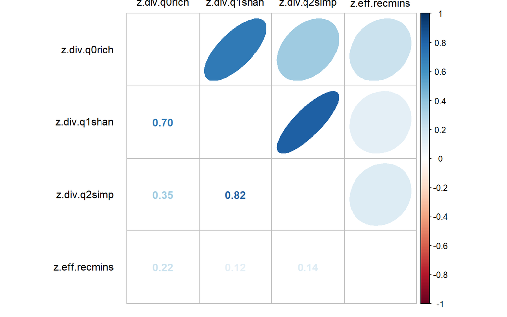

```r
m2 <- cor(site_cov, method = "spearman")
corrplot.mixed(
  m2,
  upper = "ellipse",
  lower = "number",
  tl.pos = "lt",
  tl.col = "black",
  tl.offset = 1,
  tl.srt = 0
)
```

## 9 Models

se ajusta un modelo global completo y en este caso un segundo modelo simplificado en base al AIC restringiendose a variables con baja correlacion

### 9.1 Global model

```r
glob.mod <- occu(
  formula = ~ effort ~ z.div.q0rich + z.div.q1shan + z.div.q2simp + z.eff.recmins,
  data = ategeo
)
summary(glob.mod)
```

```
##
## Call:
## occu(formula = ~effort ~ z.div.q0rich + z.div.q1shan + z.div.q2simp +
##     z.eff.recmins, data = ategeo)
##
## Occupancy (logit-scale):
##               Estimate    SE      z P(>|z|)
## (Intercept)      0.176 0.414  0.425  0.6710
## z.div.q0rich    -0.886 0.765 -1.159  0.2464
## z.div.q1shan     1.176 1.187  0.991  0.3218
## z.div.q2simp    -0.297 0.903 -0.328  0.7427
## z.eff.recmins    1.965 1.040  1.889  0.0589
##
## Detection (logit-scale):
##             Estimate    SE      z  P(>|z|)
## (Intercept)   -1.261 0.122 -10.31 6.63e-25
## effort         0.218 0.120   1.81 6.97e-02
##
## AIC: 587.1236
## Number of sites: 42
```

### 9.2 Fitted Model

```r
occu.sm <- occu(
  formula = ~ effort ~ z.div.q2simp + z.eff.recmins,
  data = ategeo
)
summary(occu.sm)
```

```
##
## Call:
## occu(formula = ~effort ~ z.div.q2simp + z.eff.recmins, data = ategeo)
##
## Occupancy (logit-scale):
##               Estimate    SE     z P(>|z|)
## (Intercept)      0.240 0.398 0.603  0.5462
## z.div.q2simp     0.455 0.376 1.211  0.2258
## z.eff.recmins    1.762 0.968 1.820  0.0688
##
## Detection (logit-scale):
##             Estimate    SE      z  P(>|z|)
## (Intercept)   -1.261 0.122 -10.31 6.62e-25
## effort         0.218 0.120   1.81 6.99e-02
##
## AIC: 584.541
## Number of sites: 42
```

```r
# probabilidad de detección
estimate.p.nm <- occu.sm@estimates@estimates$det@estimates
p <- plogis(estimate.p.nm)
p
```

```
## (Intercept)      effort
##   0.2208105   0.5542955
```

```r
# probabilidad de ocupación
estimate.psi.nm <- occu.sm@estimates@estimates$state@estimates
psi <- plogis(estimate.psi.nm)
psi
```

```
##   (Intercept)  z.div.q2simp z.eff.recmins
##     0.5597576     0.6119102     0.8534629
```

## 10 Prediction across Simpson birds diversity

se predice la ocupación del mono araña en base a una métrica de diversidad de aves (q2 -> Simpson) mientras se controla por esfuerzo de muestreo

```r
newdata_simpson <- data.frame(
  z.div.q2simp = seq(
    min(site_cov$z.div.q2simp, na.rm = TRUE),
    max(site_cov$z.div.q2simp, na.rm = TRUE),
    by = 0.01
  ),
  z.eff.recmins = mean(site_cov$z.eff.recmins, na.rm = TRUE),
  effort = mean(as.matrix(effort), na.rm = TRUE)
)

predict_simpson.cov <- cbind(
  predict(occu.sm, newdata = newdata_simpson, type = "state"),
  newdata_simpson
)

head(predict_simpson.cov)
```

|  | Predicted | SE | lower | upper | z.div.q2simp | z.eff.recmins | effort |
| --- | --- | --- | --- | --- | --- | --- | --- |
| 1 | 0.3597860 | 0.1725272 | 0.1146268 | 0.7092494 | -1.793068 | -1.192751e-17 | -6.711428e-18 |
| 2 | 0.3608355 | 0.1720117 | 0.1157276 | 0.7089000 | -1.783068 | -1.192751e-17 | -6.711428e-18 |
| 3 | 0.3618864 | 0.1714942 | 0.1168364 | 0.7085525 | -1.773068 | -1.192751e-17 | -6.711428e-18 |
| 4 | 0.3629386 | 0.1709747 | 0.1179533 | 0.7082069 | -1.763068 | -1.192751e-17 | -6.711428e-18 |
| 5 | 0.3639920 | 0.1704533 | 0.1190783 | 0.7078634 | -1.753068 | -1.192751e-17 | -6.711428e-18 |
| 6 | 0.3650468 | 0.1699300 | 0.1202114 | 0.7075219 | -1.743068 | -1.192751e-17 | -6.711428e-18 |

### 10.1 Plot predicted ocupancy

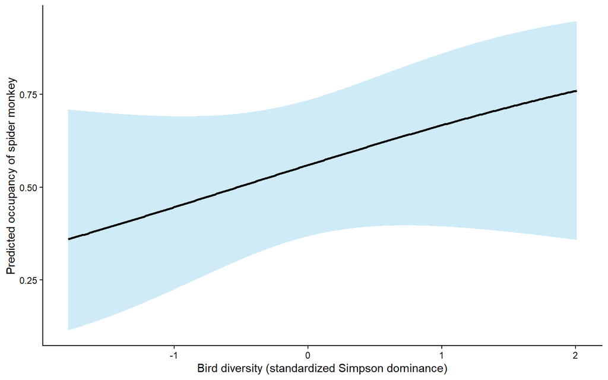

```r
ggplot(data = predict_simpson.cov, aes(x = z.div.q2simp, y = Predicted)) +
  geom_ribbon(aes(ymin = lower, ymax = upper), fill = "skyblue", alpha = 0.4) +
  geom_line(color = "black", linewidth = 1) +
  labs(
    x = "Bird diversity (standardized Simpson dominance)",
    y = "Predicted occupancy of spider monkey"
  ) +
  theme_classic()
```